# Chapter 07, Problem Set Key

### 7.4

The proportion of *Daphnia* infected duing a period of 15 days is, in sequence, 0.01, 0.03, 0.03, 0.1, 0.14, 0.3, 0.3, 0.58, 0.7, 0.7, 0.92, 0.92, 0.96, 0.97, 099, 0.99. Plot the time series.

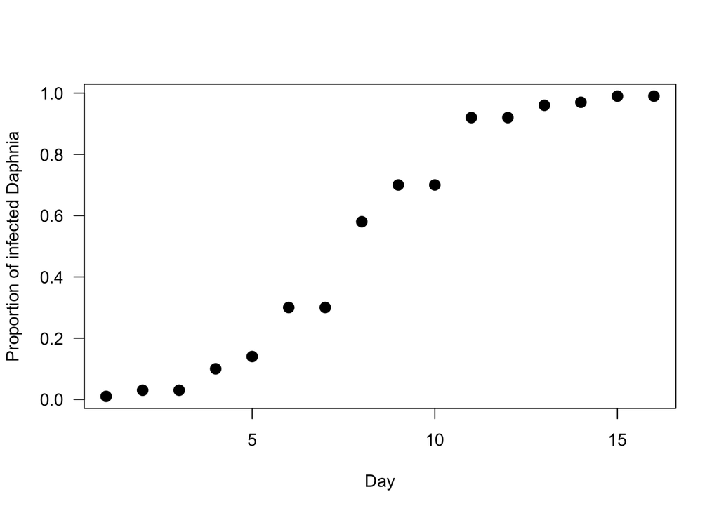

```r
daph <- c(0.01, 0.03, 0.03, 0.1, 0.14, 0.3, 0.3, 0.58, 0.7, 0.7, 0.92, 0.92, 0.96, 0.97, 0.99, 0.99)
plot(x = 1:length(daph), y = daph, las = 1, xlab = "Day", ylab = "Proportion of infected Daphnia", pch = 16, cex = 1.5)
```

### 7.5

$$I_t = \frac{I_0}{I_0 + (1 - I_0)\exp(-\beta t)} \\
(I_0 + (1 - I_0)\exp(-\beta t))I_t = I_0 \\
I_tI_0 + I_t(1 - I_0)\exp(-\beta t) = I_0 \\
I_t(1 - I_0)\exp(-\beta t) = I_0 - I_tI_0 \\
(1 - I_0)\exp(-\beta t) = \frac{I_0 - I_tI_0}{I_t} \\
\exp(-\beta t) = \frac{I_0 - I_tI_0}{I_t(1 - I_0)} \\
-\beta t = \log \left(\frac{I_0 - I_tI_0}{I_t(1 - I_0)}\right) \\
\beta t = -\log \left(\frac{I_0 - I_tI_0}{I_t(1 - I_0)}\right) \\
\beta = -\log \left(\frac{I_0 - I_tI_0}{I_t(1 - I_0)}\right)t^{-1} \\$$

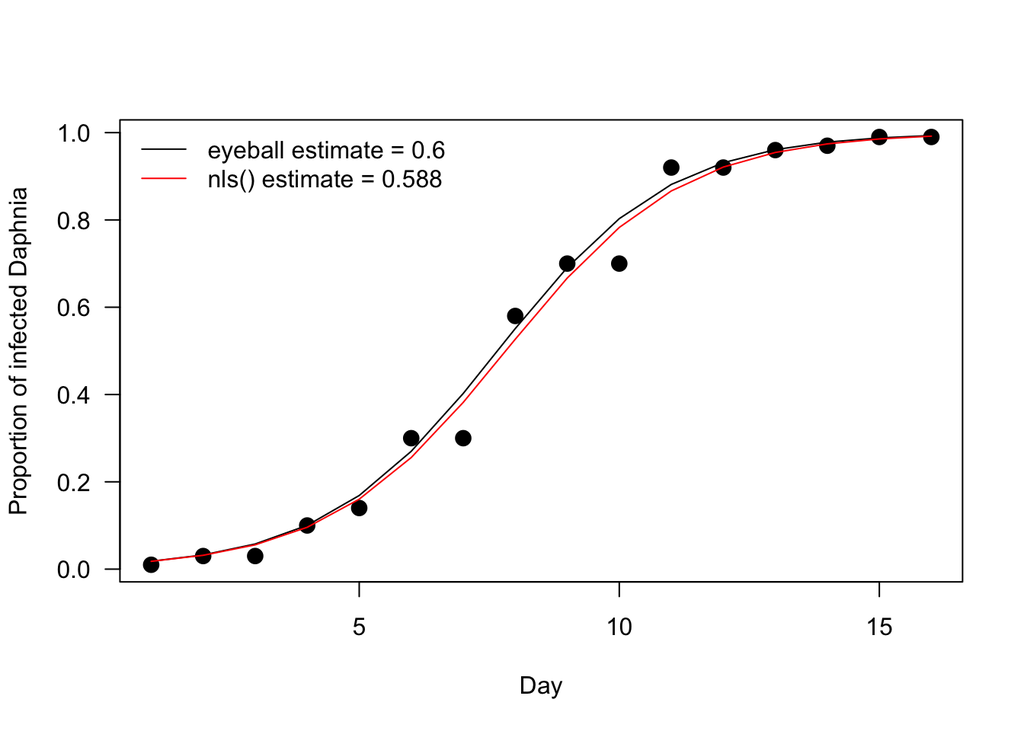

```r
daph <- c(0.01, 0.03, 0.03, 0.1, 0.14, 0.3, 0.3, 0.58, 0.7, 0.7, 0.92, 0.92, 0.96, 0.97, 0.99, 0.99)

# Eyeball estimate
I_0 <- min(daph)
time_seq <- 1:length(daph)
beta <- 0.6
It <- I_0 / (I_0 + (1 - I_0)*exp(-beta*time_seq))

plot(x = time_seq, y = daph, las = 1, xlab = "Day", ylab = "Proportion of infected Daphnia", pch = 16, cex = 1.5)
lines(x = time_seq, y = It)

# nls estimate
nls_beta <- coefficients(
  nls(formula =
        daph ~ I_0 / (I_0 + (1 -I_0)*exp(-beta*time_seq))
        , start = c(beta = 0.6)
  ))

It_nls <- I_0 / (I_0 + (1 - I_0)*exp(-nls_beta*time_seq))

lines(x = time_seq, y = It_nls, col = "red")
legend(x = "topleft", lty = 1, col = c("black", "red"), legend = c("eyeball estimate = 0.6", paste0("nls() estimate = ", sprintf(x = nls_beta, fmt = "%0.3f"))), bty = "n", cex = 1)
```

### 7.6

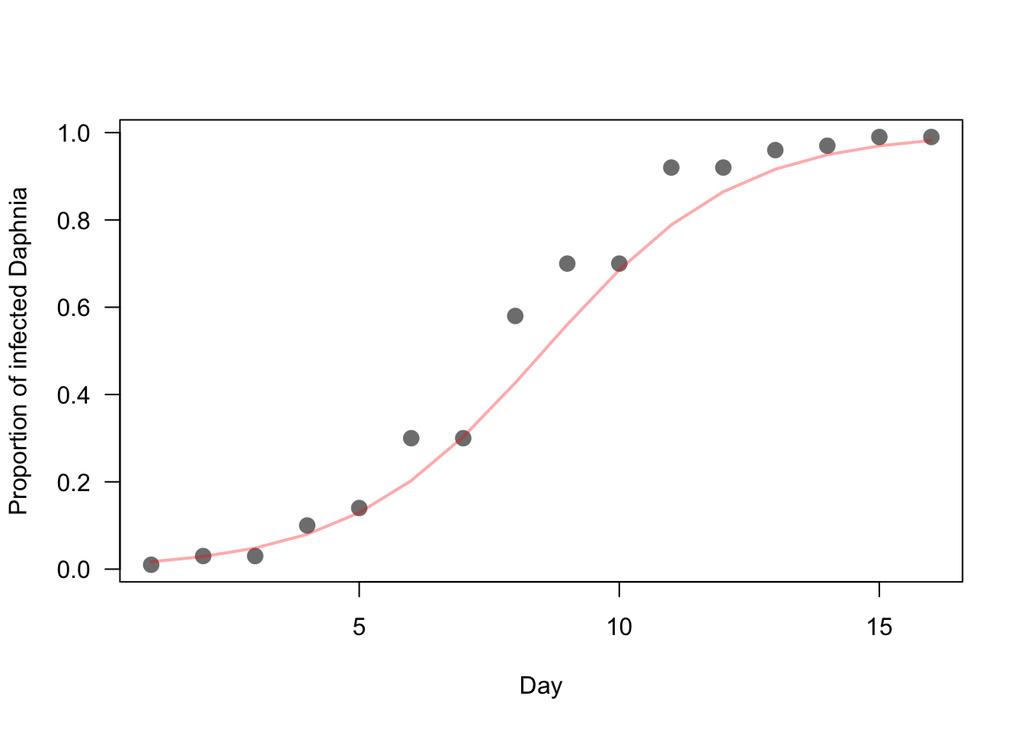

```r
It <- c(0.01, 0.03, 0.03, 0.1, 0.14, 0.3, 0.3, 0.58, 0.7, 0.7, 0.92, 0.92, 0.96, 0.97, 0.99, 0.99)
I0 <- It[1]
days <- 1:length(It)
beta_est <- mean(-log( (I0 - I0*It) / (It*(1 - I0)) )/days)
It_pred <- I_0 / (I_0 + (1 - I_0)*exp(-beta_est*days))
plot(x = days, y = It, pch = 16, col = "grey50", cex = 1.5, las = 1, xlab = "Day", ylab = "Proportion of infected Daphnia")
  lines(x = days, y = It_pred, col = "#FF000055", lwd = 2)
```

### 7.7

Equation 1 is a perfectly fine representation of the accumualtion of infected individuals in the population. What equation would describe the rate of change in the number of susceptibles in the population? What would be the integrated form of that equation (think about 7.5 and single spiecies models)?

The equation would be $\frac{dS}{dt} = - \beta SI$.

Along the lines of reasoning of transforming $S$ to $N-1$ for equation 1 and 7.5, we can do the same for $\frac{dS}{dt} = - \beta SI$. We know that $N = S + I$, so $I = N - S$. Substituting that into $\frac{dS}{dt} = - \beta SI$ we arrive at $\frac{dS}{dt} = - \beta S(N - S)$. And, like in equation 1, we are working with proportions and can convert $N$ to 1. This is the same form as equation 1, which is logistic, and we can similarly integrate it
$$S_t = \frac{S_0}{(1 - S_0)\exp (\beta t) + S_0}.$$
The only major difference is that $\beta$ is now positive.

### 7.8

Begin with a very small infection ($I_0 = 0.001$) and use the integrated form of the mass action equation (the equation in exercise 7.5) to compute the time course for the susceptible population, with $\beta = 1$, then with $\beta = 0.1$. Plot the time series.

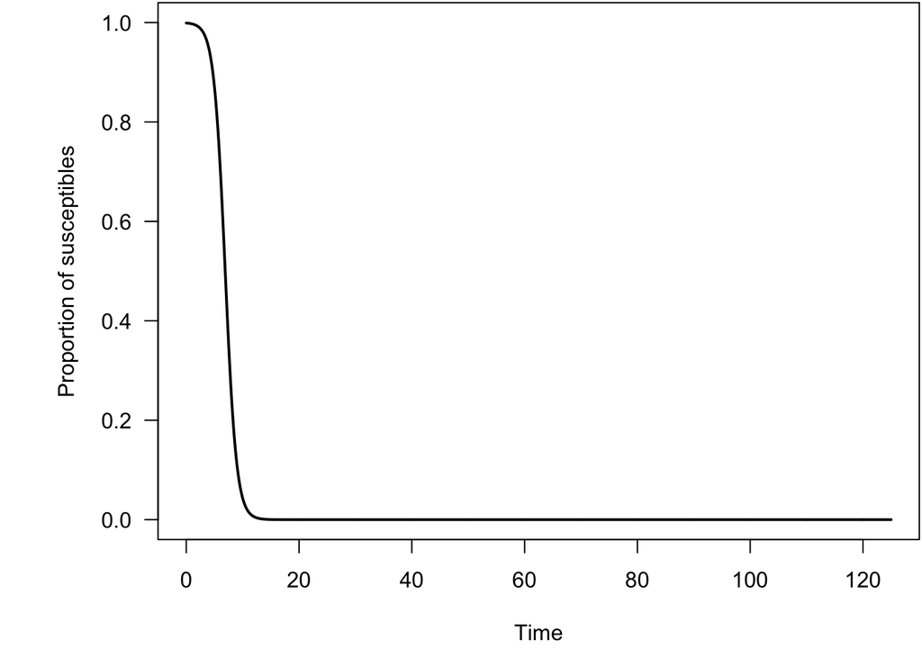

```r
times <- seq(from = 0, to = 125, by = 0.1)
I0 <- 0.001
beta_1 <- 1
beta_0.1 <- 0.1

It_beta_1 <- I0 / ((1 - I0)*exp(-beta_1*times) + I0)
It_beta_0.1 <- I0 / ((1 - I0)*exp(-beta_0.1*times) + I0)

St_beta_1 <- 1 - It_beta_1
St_beta_0.1 <- 1 - It_beta_0.1


par(mar = c(4.5, 6, 0.1, 0.1))
plot(x = times, y = St_beta_1, las = 1, xlab = "Time", ylab = "Proportion of susceptibles", type = "l", lwd = 2, ylim = c(0, 1))
```

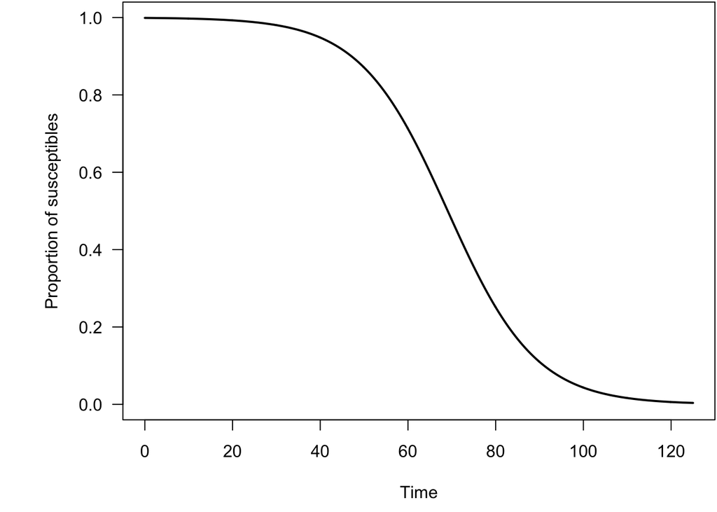

```r
plot(x = times, y = St_beta_0.1, las = 1, xlab = "Time", ylab = "Proportion of susceptibles", type = "l", lwd = 2, ylim = c(0, 1))
```

## 7.9

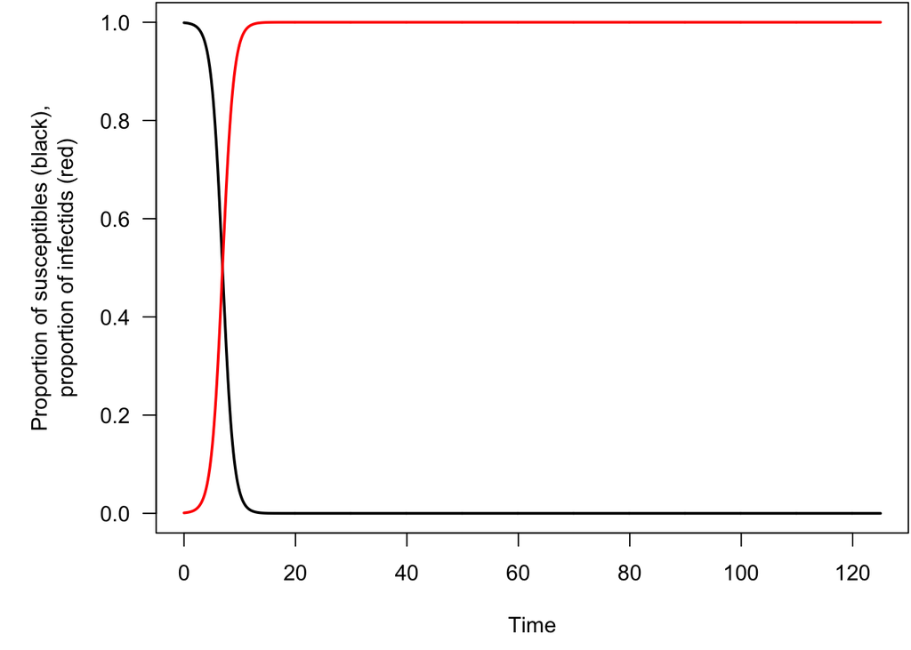

```r
times <- seq(from = 0, to = 125, by = 0.1)
I0 <- 0.001
beta_1 <- 1
beta_0.1 <- 0.1

It_beta_1 <- I0 / ((1 - I0)*exp(-beta_1*times) + I0)
It_beta_0.1 <- I0 / ((1 - I0)*exp(-beta_0.1*times) + I0)

St_beta_1 <- 1 - It_beta_1
St_beta_0.1 <- 1 - It_beta_0.1


par(mar = c(4.5, 6, 0.1, 0.1))
plot(x = times, y = St_beta_1, las = 1, xlab = "Time", ylab = "Proportion of susceptibles (black),\nproportion of infectids (red)", type = "l", lwd = 2, ylim = c(0, 1))
  lines(x = times, y = It_beta_1, col = "red", lwd = 2)
```

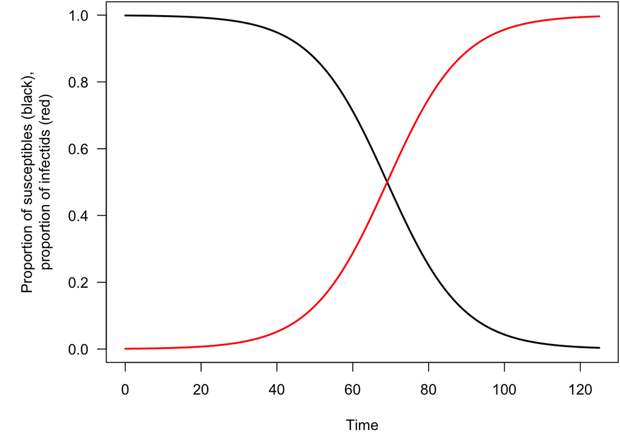

```r
plot(x = times, y = St_beta_0.1, las = 1, xlab = "Time", ylab = "Proportion of susceptibles (black),\nproportion of infectids (red)", type = "l", lwd = 2, ylim = c(0, 1))
  lines(x = times, y = It_beta_0.1, col = "red", lwd = 2)
```

## 7.13

Use equation 5 or 4b to determine the critical value of $S$ at which the disease will begin to decline. How does that value relate to $R_0$?

If you set the derivative to 0 the rate of change of $I$ is $0$. If the right-hand side is negative, the population is shrinking, and growing if the right-hand side is positive.

## 7.14

At the onset of an infection, public health officials can intervene to attempt to encourage changes in behavior patterns that will decrease host-to-host contact. Mathematically, how will this affect the critical $S$ for which the disease starts declining?

## 7.15

Suppose that individuals can be switched directly from susceptible to resistant without having to become infected. How would that affect equations 4a and 4c?

Write down what the right-hand side of the equations:
$$\frac{\mathrm{d}(S)}{\mathrm{d}t} = \\ \frac{\mathrm{d}(R)}{\mathrm{d}t} =$$

Write down what the right-hand side of the equations:
$$\frac{\mathrm{d}(S)}{\mathrm{d}t} = -\beta SI - \gamma S\\
\frac{\mathrm{d}(S)}{\mathrm{d}t} = \beta SI - \nu I\\
\frac{\mathrm{d}(R)}{\mathrm{d}t} = \nu I + \gamma S$$

This would be equivalent of vaccinating a constant proportion of the population per unit time.